# Final_Project

Euchie Jn Pierre

2022-12-29

## **Methodology**

The dataset for this project focuses on the systematic global assessment of reef fish communities by the Reef Life Survey program, which was collected by Graham J Edgar and Rick D Stuart-Smith in 2014. In the original dataset, the authors recorded the abundance of 2367 reef fish species across 11 realms. Other information such as the family the species came from, and the transects, sites, countries, and ecoregions where they were found were also recorded (15 columns and 134759 rows). This dataset was manipulated to contain only the 11 realms and accumulated abundances for the 2367 distinct reef fish species. This was to carry out our rarefaction and extrapolation for the abundance of species across the 11 realms. This analysis was done using the iNEXT package by Anne Chao (Chao et al.2014) in the R software (Version 2022.12.0+353 (2022.12.0+353).

After manipulating the dataset, the integrated sample-sized-based rarefaction and extrapolation Hill numbers for each of the realms were calculated then integrated curves were constructed according to the base sample size. The base sample size is double the smallest reference sample size out of the 11 assemblages.Constructing the sampling curve allows for reliable comparisons for any sample size up to an abundance of the base sample size.

The coverage-based diversities of the 11 realms were then compared for species richness (q=0), Shannon diversity (q=1), and Simpson’s diversity (q=2) according to the ‘‘base coverage’’ which is the lowest coverage for doubled reference sample sizes. The coverage refers to the total relative abundances of the observed species, or the proportion of the total number of individuals in an assemblage that belong to species represented in the sample.

## **Importing the dataset**

```r
# Preparing data----
reef_0 <- read_csv("/Users/mrnobody/Documents/NTU Third Semester/Eco stats in Rproj/reef_fish.csv",show_col_types = FALSE)
reef_0 <- as.data.frame(reef_0)
head(reef_0)
```

```
##   SiteCode                Site   SiteLat SiteLong   Country          Ecoregion
## 1     CG10 Steves Bommie (668) -31.68152  152.912 Australia Manning-Hawkesbury
## 2     CG10 Steves Bommie (668) -31.68152  152.912 Australia Manning-Hawkesbury
## 3     CG10 Steves Bommie (668) -31.68152  152.912 Australia Manning-Hawkesbury
## 4     CG10 Steves Bommie (668) -31.68152  152.912 Australia Manning-Hawkesbury
## 5     CG10 Steves Bommie (668) -31.68152  152.912 Australia Manning-Hawkesbury
## 6     CG10 Steves Bommie (668) -31.68152  152.912 Australia Manning-Hawkesbury
##                   Realm SurveyID Depth SurveyDate Diver                   Taxon
## 1 Temperate Australasia  2000859    30  17-May-09    MC  Acanthistius ocellatus
## 2 Temperate Australasia  2000859    30  17-May-09    MC Acanthopagrus australis
## 3 Temperate Australasia  2000859    30  17-May-09   DJA      Achoerodus viridis
## 4 Temperate Australasia  2000859    30  17-May-09   DJA   Atypichthys strigatus
## 5 Temperate Australasia  2000859    30  17-May-09    MC   Atypichthys strigatus
## 6 Temperate Australasia  2000859    30  17-May-09   DJA   Cheilodactylus fuscus
##             Family Block Total
## 1       Serranidae     2     1
## 2         Sparidae     2     5
## 3         Labridae     1     2
## 4      Scorpididae     1   100
## 5      Scorpididae     2     5
## 6 Cheilodactylidae     1   200
```

## **Manipulating data**

```r
reef_1 <- reef_0[,c('Realm','Taxon','Total')]
reef_2<-reef_1 %>%
  group_by(Taxon,Realm) %>%
dplyr::summarise(Total = sum(Total))
```

```r
reef_3 <-reef_2%>%
  group_by(Taxon, Realm) %>%
  mutate(row =row_number()) %>%
  tidyr::pivot_wider(names_from = Realm, values_from = Total) %>%
  select(-row) %>%
  replace(is.na(.), 0) %>%
  as.data.frame()
reef_fish <- reef_3[,-1]
rownames(reef_fish) <- reef_3[,1]
dim(reef_fish)
```

```
## [1] 2367   11
```

```r
head(reef_fish)
```

```
##                       Eastern Indo-Pacific Central Indo-Pacific
## Abudefduf abdominalis                   49                    0
## Abudefduf bengalensis                    0                 3025
## Abudefduf concolor                       0                    0
## Abudefduf conformis                    462                    0
## Abudefduf luridus                        0                    0
## Abudefduf notatus                        0                    0
##                       Temperate Australasia Tropical Eastern Pacific
## Abudefduf abdominalis                     0                        0
## Abudefduf bengalensis                   343                        0
## Abudefduf concolor                        0                       23
## Abudefduf conformis                       0                        0
## Abudefduf luridus                         0                        0
## Abudefduf notatus                         0                        0
##                       Temperate Northern Atlantic Western Indo-Pacific
## Abudefduf abdominalis                           0                    0
## Abudefduf bengalensis                           0                    0
## Abudefduf concolor                              0                    0
## Abudefduf conformis                             0                    0
## Abudefduf luridus                           12575                    0
## Abudefduf notatus                               0                  458
##                       Tropical Atlantic Temperate South America
## Abudefduf abdominalis                 0                       0
## Abudefduf bengalensis                 0                       0
## Abudefduf concolor                    0                       0
## Abudefduf conformis                   0                       0
## Abudefduf luridus                     0                       0
## Abudefduf notatus                     0                       0
##                       Temperate Southern Africa Temperate Northern Pacific
## Abudefduf abdominalis                         0                          0
## Abudefduf bengalensis                         0                          0
## Abudefduf concolor                            0                          0
## Abudefduf conformis                           0                          0
## Abudefduf luridus                             0                          0
## Abudefduf notatus                             0                          0
##                       Arctic
## Abudefduf abdominalis      0
## Abudefduf bengalensis      0
## Abudefduf concolor         0
## Abudefduf conformis        0
## Abudefduf luridus          0
## Abudefduf notatus          0
```

## **Results**

After comparing the 11 assemblages (realms) with Hill number order q = 0, 1, 2. The basic data information (See table below) revealed that the lowest number of individuals observed among the 11 realms was 18 individuals from the Arctic realm. Whereas, the highest was 1,498,462 individuals from the Temperate Australasia region. The lowest richness observed among the 11 assemblages standardized to the same area was 5 species, which again came from the Artic realm. However, for the highest richness observed, the Central Indo-Pacific topped the realms with 1146 species.

```r
# Specifying series of samples sizes for quicker calculation using bootstrapping ----
m <- c(1, 25000, 50000, 100000, 150000, 200000, 250000)
# to return basic data information including the reference sample size (n), observed species richness (S.obs), sample coverage estimate for the reference sample (SC), and the first ten frequency counts (f1‐f10)
rf.raref<-iNEXT(reef_fish,q=c(0,1,2), datatype="abundance", size=m)
rf.raref$DataInfo
```

```
##                     Assemblage       n S.obs     SC  f1 f2 f3 f4 f5 f6 f7 f8 f9
## 1         Eastern Indo-Pacific  392347   532 0.9998  68 33 18 21 13 15  4  8  2
## 2         Central Indo-Pacific 1104287  1146 0.9999 106 71 40 31 32 41 24 18 10
## 3        Temperate Australasia 1498462   793 0.9999 104 55 35 26 19 19 21 13 12
## 4     Tropical Eastern Pacific  684437   197 1.0000  26 10  5  8  5  2  3  2  4
## 5  Temperate Northern Atlantic  106701   123 0.9999  14 11  5  9  1  1  1  4  3
## 6         Western Indo-Pacific  226425   517 0.9997  63 45 22 29 19  9 12 13  6
## 7            Tropical Atlantic  188010   196 0.9999  23 12 11  5  3  6  6  2  3
## 8      Temperate South America    7004    22 0.9996   3  3  0  0  0  1  1  0  0
## 9    Temperate Southern Africa    6338    37 0.9994   4  4  4  0  1  1  1  0  0
## 10  Temperate Northern Pacific   33588   158 0.9987  43 17  5  5  3  1  2  8  1
## 11                      Arctic      18     5 0.9006   2  0  1  0  1  0  0  1  0
##    f10
## 1   10
## 2   16
## 3   12
## 4    2
## 5    0
## 6    6
## 7    3
## 8    1
## 9    0
## 10   3
## 11   0
```

```r
# calculating the diversity estimates for the minimum among all doubled reference sample sizes.
rf.indi0 <- estimateD (reef_fish, data = 'abundance', base = 'size', level = NULL)
rf.indi <- rf.indi0[rf.indi0$Order.q == '0',]
rf.indi
```

```
##                     Assemblage  m        Method Order.q        SC        qD
## 1         Eastern Indo-Pacific 36   Rarefaction       0 0.5783579 21.811202
## 4         Central Indo-Pacific 36   Rarefaction       0 0.4042364 27.332910
## 7        Temperate Australasia 36   Rarefaction       0 0.6525230 19.259533
## 10    Tropical Eastern Pacific 36   Rarefaction       0 0.7756111 13.964845
## 13 Temperate Northern Atlantic 36   Rarefaction       0 0.8544205 12.016316
## 16        Western Indo-Pacific 36   Rarefaction       0 0.6652823 17.897748
## 19           Tropical Atlantic 36   Rarefaction       0 0.6821056 19.085483
## 22     Temperate South America 36   Rarefaction       0 0.9400803  6.894070
## 25   Temperate Southern Africa 36   Rarefaction       0 0.8925705  9.250539
## 28  Temperate Northern Pacific 36   Rarefaction       0 0.7407486 16.250356
## 31                      Arctic 36 Extrapolation       0 0.9865733  5.816891
##       qD.LCL    qD.UCL
## 1  21.770150 21.852255
## 4  27.313784 27.352037
## 7  19.236410 19.282656
## 10 13.938390 13.991301
## 13 11.950970 12.081663
## 16 17.838276 17.957220
## 19 19.029407 19.141558
## 22  6.723965  7.064175
## 25  9.007291  9.493786
## 28 16.120135 16.380577
## 31  3.815416  7.818366
```

```r
# choose species richness (q = 0); the other values refer to Shannon and Simpson diversity (q = 1 and q = 2, respectively)
```

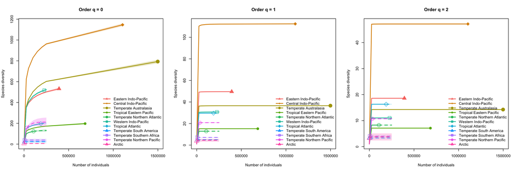

```r
# Plotting the rarefaction curves
par (mfrow = c(1,3))
plot (rf.raref, type = 1)
```

```r
# calculating the diversity estimates for the minimum among the coverage values for samples extrapolated to double the size of the reference sample.
rf.cove0 <- estimateD (reef_fish, data = 'abundance', base = 'coverage', level = NULL)
rf.cove <- rf.cove0[rf.cove0$Order.q == '0',]
rf.cove
```

```
##                     Assemblage          m        Method Order.q        SC
## 1         Eastern Indo-Pacific  4960.0550   Rarefaction       0 0.9865733
## 4         Central Indo-Pacific 10951.8702   Rarefaction       0 0.9865733
## 7        Temperate Australasia  5571.2809   Rarefaction       0 0.9865733
## 10    Tropical Eastern Pacific  1363.5010   Rarefaction       0 0.9865733
## 13 Temperate Northern Atlantic  1117.8815   Rarefaction       0 0.9865733
## 16        Western Indo-Pacific  5653.7498   Rarefaction       0 0.9865733
## 19           Tropical Atlantic  1556.7800   Rarefaction       0 0.9865733
## 22     Temperate South America   228.7139   Rarefaction       0 0.9865733
## 25   Temperate Southern Africa   422.4188   Rarefaction       0 0.9865733
## 28  Temperate Northern Pacific  1527.9551   Rarefaction       0 0.9865733
## 31                      Arctic    36.0000 Extrapolation       0 0.9865733
##            qD     qD.LCL     qD.UCL
## 1  243.479128 241.929559 245.028698
## 4  500.726422 498.139179 503.313664
## 7  231.667099 230.318738 233.015461
## 10  67.941025  67.577814  68.304236
## 13  46.528204  45.501568  47.554840
## 16 235.096328 231.406027 238.786629
## 19  81.140936  79.927543  82.354330
## 22  11.700433  11.058672  12.342195
## 25  22.059731  20.947539  23.171924
## 28  70.831511  68.282886  73.380136
## 31   5.816891   3.683306   7.950476
```

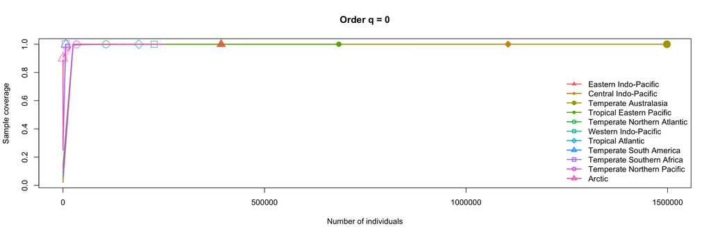

```r
plot (rf.raref, type = 2)
```

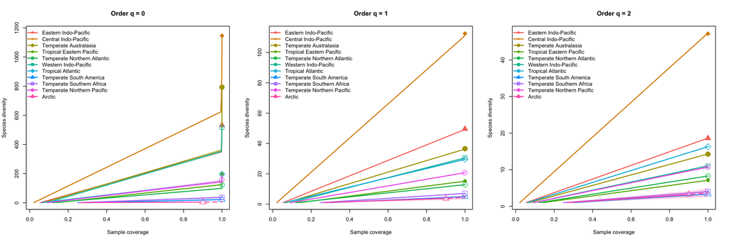

```r
par (mfrow = c(1,3))
plot (rf.raref, type = 3)
```

## **Discussion**

In order to better explain the results received earlier, it is worth mentioning that reef fish richness increases with coral diversity. There is evidence of a significant positive correlation between the two variables (r = 0.65, p < 0.0001)(Strona G et al. 2021). Reef fish species, such as obligate corallivores (Sano et al. 1987, Sano 2000, Pratchett 2007) thrive in coral structures that are topographically or structurally complex. This is because the complexity in structures serves as a place of refuge (sano 2000). This goes on to show that reef fish are vulnerable to coral loss which varies per region or realm. Some realms have very complex coral structures which are usually threatened by environmental disturbances like storms or anthropogenic practices such as coastal developments. The highest vulnerability of reef fish species was detected in the central Pacific due to the significant amount of coral loss experienced. However, in the western Indian, central Indo-Pacific, and tropical eastern Pacific vulnerability was rated as intermediate, with the western Atlantic being moderate (Strona G et al. 2021). The complex coral structures can partially help to explain why these realms, specifically the central indo-pacific harbors thousands of different species of reef fish, helping to increase their species richness and diversity. More research would be needed to factor in other variables that would negatively or positively influence species richness and diversity. These may include but wont be limited to water temperature, salinity, PH, distance from coastline, depth and maybe human activities.

## Future implications:

The results of this project can help to properly monitor realms in other to save species that are about to go extinct and maybe learn from those realms, based on the management practices that they use in other to increase species diversity. From this project, based on the results, I can suggest that this data can be used to build a predictive model for species richness and diversity especially in the face of climate change which has already started to adversely affect coral structures. This can in-turn lead to reef fish species abundance and diversity decline. A predictive model could help stakeholders act ahead of time to save species via mitigation or adaptation practices.

## **Acknowledgements**

I would like to thank Dr Vianney Denis and his lab teaching assistants for their patience and edification throughout the semester, and for providing the data set by Graham J Edgar and Rick D Stuart-Smith, titled, “the systematic global assessment of reef fish communities by the Reef Life Survey program”.

## **References**

Chao, A., Gotelli, N.J., Hsieh, T.C., Sander, E.L., Ma, K.H., Colwell, R.K. & Ellison, A.M. (2014) Rarefaction and extrapolation with Hill numbers: a framework for sampling and estimation in species diversity studies. Ecological Monographs, 84, 45–67.

Goldman, B. and Talbot, F.I. (1976) Aspects of ecology of the coral reef fishes. In: Jones, O.A. and Endean, R., Eds., Biology and Geology of Coral Reefs, Academic Press, New York, 125-154.

Lefcheck, J.S., Edgar, G.J., Stuart-Smith, R.D. et al. Species richness and identity both determine the biomass of global reef fish communities. Nat Commun 12, 6875 (2021). https://doi.org/10.1038/s41467-021-27212-9

Pratchett MS (2007) Dietary selection by coral-feeding butterflyfishes (Chaetodontidae) on the Great Barrier Reef, Australia. Raffles Bull Zool S14:171–176

Sano M, Shimizu M, Nose Y (1987) Long-term effects of destruction of hermatypic corals by Acanthaster planci infestation on reef fish communities at Iriomote Island, Japan. Mar Ecol Prog Ser 37:191–199

Sano M (2000) Stability of reef fish assemblages: responses to coral recovery after catastrophic predation by Acanthaster planci. Mar Ecol Prog Ser 198:121–130

Strona G et al. 2021 Global tropical reef fish richness could decline by around half if corals are lost. Proc. R. Soc. B288: 20210274. https://doi.org/10.1098/rspb.2021.0274